# Lab 5 Notes

Week 5 Linear Models

## Review from last week

Prediction Intervals - Interval estimating taking “one more sample” based on a parent sample -Dependent on sample distribution

Replication Interval -

Tolerance Interval - Contains a certain percent of the data with a certain certainty

Nonparametric Interval - Dont assume anyting about distribution

## Linear Regression

Simple Linear Regression $y_i = \beta_0 + \beta_1 * x + \epsilon_i$ Goal: estimate $\beta_0$ and $\beta_1$

Transformations can allow us to use linear models for many uses

### Basic Linear Model

```r
summary(iris)
```

```
  Sepal.Length    Sepal.Width     Petal.Length    Petal.Width          Species
 Min.   :4.300   Min.   :2.000   Min.   :1.000   Min.   :0.100   setosa    :50
 1st Qu.:5.100   1st Qu.:2.800   1st Qu.:1.600   1st Qu.:0.300   versicolor:50
 Median :5.800   Median :3.000   Median :4.350   Median :1.300   virginica :50
 Mean   :5.843   Mean   :3.057   Mean   :3.758   Mean   :1.199
 3rd Qu.:6.400   3rd Qu.:3.300   3rd Qu.:5.100   3rd Qu.:1.800
 Max.   :7.900   Max.   :4.400   Max.   :6.900   Max.   :2.500
```

```r
model1 = lm(Sepal.Length~Sepal.Width, data = iris)
summary(model1)
```

```
Call:
lm(formula = Sepal.Length ~ Sepal.Width, data = iris)

Residuals:
    Min      1Q  Median      3Q     Max
-1.5561 -0.6333 -0.1120  0.5579  2.2226

Coefficients:
            Estimate Std. Error t value Pr(>|t|)
(Intercept)   6.5262     0.4789   13.63   <2e-16 ***
Sepal.Width  -0.2234     0.1551   -1.44    0.152
---
Signif. codes:  0 ‘***’ 0.001 ‘**’ 0.01 ‘*’ 0.05 ‘.’ 0.1 ‘ ’ 1

Residual standard error: 0.8251 on 148 degrees of freedom
Multiple R-squared:  0.01382,   Adjusted R-squared:  0.007159
F-statistic: 2.074 on 1 and 148 DF,  p-value: 0.1519
```

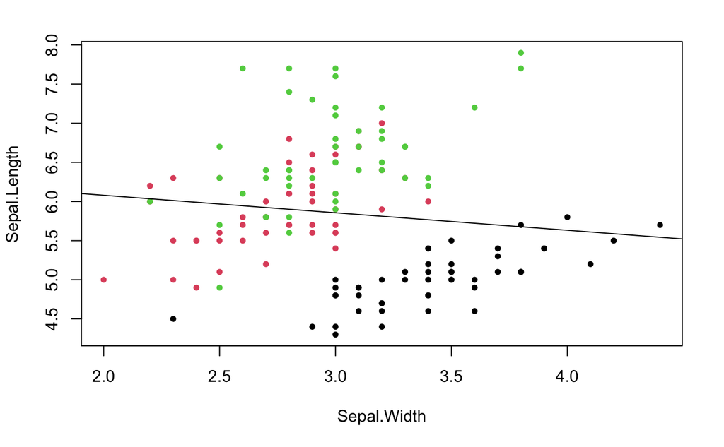

```r
#Plot
plot(Sepal.Length~Sepal.Width, data = iris, col = Species, pch = 20)
abline(model1)
```

```r
NA
NA
```

### Fitting Different LInes for different species

```r
#Fit different lines per species
setosaModel = lm(Sepal.Length~Sepal.Width, data = iris, subset = Species == "setosa")
summary(setosaModel)
```

```
Call:
lm(formula = Sepal.Length ~ Sepal.Width, data = iris, subset = Species ==
    "setosa")

Residuals:
     Min       1Q   Median       3Q      Max
-0.52476 -0.16286  0.02166  0.13833  0.44428

Coefficients:
            Estimate Std. Error t value Pr(>|t|)
(Intercept)   2.6390     0.3100   8.513 3.74e-11 ***
Sepal.Width   0.6905     0.0899   7.681 6.71e-10 ***
---
Signif. codes:  0 ‘***’ 0.001 ‘**’ 0.01 ‘*’ 0.05 ‘.’ 0.1 ‘ ’ 1

Residual standard error: 0.2385 on 48 degrees of freedom
Multiple R-squared:  0.5514,    Adjusted R-squared:  0.542
F-statistic: 58.99 on 1 and 48 DF,  p-value: 6.71e-10
```

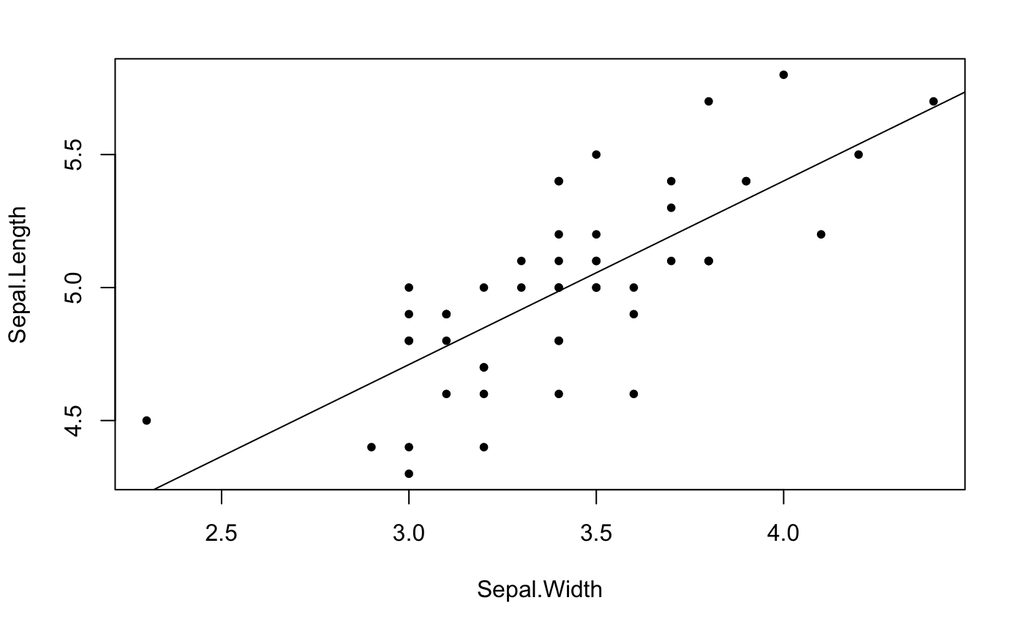

```r
plot(Sepal.Length~Sepal.Width, data = iris, col = Species, pch = 20, subset = Species == "setosa")
abline(setosaModel)
```

### Suppressing the Intercept with a -1

```r
suppressedModel = lm(Sepal.Length~Sepal.Width-1, data = iris)
suppressedModel
```

```
Call:
lm(formula = Sepal.Length ~ Sepal.Width - 1, data = iris)

Coefficients:
Sepal.Width
      1.869
```

```r
#summary(suppressedModel)
```

lm() has some funky special operations. Use I() around any math expression to be interpreted literally

```r
lm(Sepal.Length~I(Sepal.Width^2), data = iris)
```

```
Call:
lm(formula = Sepal.Length ~ I(Sepal.Width^2), data = iris)

Coefficients:
     (Intercept)  I(Sepal.Width^2)
          6.2209           -0.0396
```

### Looking at the Model Summary

```r
setosaModel$coefficients #Get coefficients
```

```
(Intercept) Sepal.Width
  2.6390012   0.6904897
```

```r
setosaModel$residuals #get residuals
```

```
          1           2           3           4           5           6           7           8           9          10          11
 0.04428474  0.18952960 -0.14856834 -0.17951937 -0.12476423  0.06808885 -0.38666629  0.01333371 -0.24142143  0.12048063  0.20618680
         12          13          14          15          16          17          18          19          20          21          22
-0.18666629  0.08952960 -0.41047040  0.39903988  0.02284400  0.06808885  0.04428474  0.43713783 -0.16286217  0.41333371 -0.09381320
         23          24          25          26          27          28          29          30          31          32          33
-0.52476423  0.18238268 -0.18666629  0.28952960  0.01333371  0.14428474  0.21333371 -0.14856834  0.02048063  0.41333371 -0.27000909
         34          35          36          37          38          39          40          41          42          43          44
-0.03905806  0.12048063  0.15143166  0.44428474 -0.22476423 -0.31047040  0.11333371 -0.05571526  0.27287240 -0.44856834 -0.05571526
         45          46          47          48          49          50
-0.16286217  0.08952960 -0.16286217 -0.24856834  0.10618680  0.08238268
```

However, its better to access this info with the respective functions

```r
coef(setosaModel)
```

```
(Intercept) Sepal.Width
  2.6390012   0.6904897
```

```r
resid(setosaModel)
```

```
          1           2           3           4           5           6           7           8           9          10          11
 0.04428474  0.18952960 -0.14856834 -0.17951937 -0.12476423  0.06808885 -0.38666629  0.01333371 -0.24142143  0.12048063  0.20618680
         12          13          14          15          16          17          18          19          20          21          22
-0.18666629  0.08952960 -0.41047040  0.39903988  0.02284400  0.06808885  0.04428474  0.43713783 -0.16286217  0.41333371 -0.09381320
         23          24          25          26          27          28          29          30          31          32          33
-0.52476423  0.18238268 -0.18666629  0.28952960  0.01333371  0.14428474  0.21333371 -0.14856834  0.02048063  0.41333371 -0.27000909
         34          35          36          37          38          39          40          41          42          43          44
-0.03905806  0.12048063  0.15143166  0.44428474 -0.22476423 -0.31047040  0.11333371 -0.05571526  0.27287240 -0.44856834 -0.05571526
         45          46          47          48          49          50
-0.16286217  0.08952960 -0.16286217 -0.24856834  0.10618680  0.08238268
```

### Scale Function

```r
lm(scale(Sepal.Length)~scale(Sepal.Width), data = iris)
```

```
Call:
lm(formula = scale(Sepal.Length) ~ scale(Sepal.Width), data = iris)

Coefficients:
       (Intercept)  scale(Sepal.Width)
        -4.355e-16          -1.176e-01
```

### Predict Function

Allows for interpolation along the line Arguments: 1. lm result 2. Must be a data frame 3. Data frame name must match the originally used name

Don’t abuse this for extrapolation

```r
predict(setosaModel, data.frame(Sepal.Width = c(2.7, 3.2, 3.7)))
```

```
       1        2        3
4.503323 4.848568 5.193813
```